# CardioGoodProject1Kaya

```python
import pandas as pd
import numpy as np
import matplotlib.pyplot as plt
import seaborn as sns
sns.set(style="darkgrid")
```

```python
df=pd.read_csv("CardioGoodFitness.csv")
```

```python
df.head(10)
```

|  | Product | Age | Gender | Education | MaritalStatus | Usage | Fitness | Income | Miles |
| --- | --- | --- | --- | --- | --- | --- | --- | --- | --- |
| 0 | TM195 | 18 | Male | 14 | Single | 3 | 4 | 29562 | 112 |
| 1 | TM195 | 19 | Male | 15 | Single | 2 | 3 | 31836 | 75 |
| 2 | TM195 | 19 | Female | 14 | Partnered | 4 | 3 | 30699 | 66 |
| 3 | TM195 | 19 | Male | 12 | Single | 3 | 3 | 32973 | 85 |
| 4 | TM195 | 20 | Male | 13 | Partnered | 4 | 2 | 35247 | 47 |
| 5 | TM195 | 20 | Female | 14 | Partnered | 3 | 3 | 32973 | 66 |
| 6 | TM195 | 21 | Female | 14 | Partnered | 3 | 3 | 35247 | 75 |
| 7 | TM195 | 21 | Male | 13 | Single | 3 | 3 | 32973 | 85 |
| 8 | TM195 | 21 | Male | 15 | Single | 5 | 4 | 35247 | 141 |
| 9 | TM195 | 21 | Female | 15 | Partnered | 2 | 3 | 37521 | 85 |

```python
df.dtypes # the code helps us understand the data type of each variable; Product, Gender, and Marital Status are object, the other variables are integer
```

```
Product          object
Age               int64
Gender           object
Education         int64
MaritalStatus    object
Usage             int64
Fitness           int64
Income            int64
Miles             int64
dtype: object
```

```python
df.shape #there are 180 rows and 9 columns
```

```
(180, 9)
```

```python
df.isnull().sum() #there is no missing value
```

```
Product          0
Age              0
Gender           0
Education        0
MaritalStatus    0
Usage            0
Fitness          0
Income           0
Miles            0
dtype: int64
```

```python
df.duplicated().sum() # there is no duplicated data
```

```
0
```

```python
df.describe()
```

|  | Age | Education | Usage | Fitness | Income | Miles |
| --- | --- | --- | --- | --- | --- | --- |
| count | 180.000000 | 180.000000 | 180.000000 | 180.000000 | 180.000000 | 180.000000 |
| mean | 28.788889 | 15.572222 | 3.455556 | 3.311111 | 53719.577778 | 103.194444 |
| std | 6.943498 | 1.617055 | 1.084797 | 0.958869 | 16506.684226 | 51.863605 |
| min | 18.000000 | 12.000000 | 2.000000 | 1.000000 | 29562.000000 | 21.000000 |
| 25% | 24.000000 | 14.000000 | 3.000000 | 3.000000 | 44058.750000 | 66.000000 |
| 50% | 26.000000 | 16.000000 | 3.000000 | 3.000000 | 50596.500000 | 94.000000 |
| 75% | 33.000000 | 16.000000 | 4.000000 | 4.000000 | 58668.000000 | 114.750000 |
| max | 50.000000 | 21.000000 | 7.000000 | 5.000000 | 104581.000000 | 360.000000 |

1. Min age of customers is 18, and the max age of customers is 50. The mean value of age is 28.78.
2. Min of education of the customers is 12, max of education of the customers is 21. The mean value of education of the customers is 15.57 years.
3. Min income is 29562 and max income is 104581.

```python
df["Product"].unique() # there are three products(TM195,TM498,TM798)
```

```
array(['TM195', 'TM498', 'TM798'], dtype=object)
```

```python
df["Gender"].unique() # a customer can be female or male
```

```
array(['Male', 'Female'], dtype=object)
```

```python
df["MaritalStatus"].unique() # a customer can be single or partnered
```

```
array(['Single', 'Partnered'], dtype=object)
```

```python
df.info() # recheck number of rows and columns, data type, and missing value
```

```
<class 'pandas.core.frame.DataFrame'>
RangeIndex: 180 entries, 0 to 179
Data columns (total 9 columns):
 #   Column         Non-Null Count  Dtype
---  ------         --------------  -----
 0   Product        180 non-null    object
 1   Age            180 non-null    int64
 2   Gender         180 non-null    object
 3   Education      180 non-null    int64
 4   MaritalStatus  180 non-null    object
 5   Usage          180 non-null    int64
 6   Fitness        180 non-null    int64
 7   Income         180 non-null    int64
 8   Miles          180 non-null    int64
dtypes: int64(6), object(3)
memory usage: 12.8+ KB
```

```python
df.groupby(by=["Product"])[["Age","Income","Usage","Miles","Fitness","Education"]].mean()
```

| Product | Age | Income | Usage | Miles | Fitness | Education |
| --- | --- | --- | --- | --- | --- | --- |
| TM195 | 28.55 | 46418.025 | 3.087500 | 82.787500 | 2.9625 | 15.037500 |
| TM498 | 28.90 | 48973.650 | 3.066667 | 87.933333 | 2.9000 | 15.116667 |
| TM798 | 29.10 | 75441.575 | 4.775000 | 166.900000 | 4.6250 | 17.325000 |

```python
df.groupby(by=["Product"])[["Age","Income","Usage","Miles","Fitness","Education"]].describe().T
```

|  | Product | TM195 | TM498 | TM798 |
| --- | --- | --- | --- | --- |
| Age | count | 80.000000 | 60.000000 | 40.000000 |
|  | mean | 28.550000 | 28.900000 | 29.100000 |
|  | std | 7.221452 | 6.645248 | 6.971738 |
|  | min | 18.000000 | 19.000000 | 22.000000 |
|  | 25% | 23.000000 | 24.000000 | 24.750000 |
|  | 50% | 26.000000 | 26.000000 | 27.000000 |
|  | 75% | 33.000000 | 33.250000 | 30.250000 |
|  | max | 50.000000 | 48.000000 | 48.000000 |
| Income | count | 80.000000 | 60.000000 | 40.000000 |
|  | mean | 46418.025000 | 48973.650000 | 75441.575000 |
|  | std | 9075.783190 | 8653.989388 | 18505.836720 |
|  | min | 29562.000000 | 31836.000000 | 48556.000000 |
|  | 25% | 38658.000000 | 44911.500000 | 58204.750000 |
|  | 50% | 46617.000000 | 49459.500000 | 76568.500000 |
|  | 75% | 53439.000000 | 53439.000000 | 90886.000000 |
|  | max | 68220.000000 | 67083.000000 | 104581.000000 |
| Usage | count | 80.000000 | 60.000000 | 40.000000 |
|  | mean | 3.087500 | 3.066667 | 4.775000 |
|  | std | 0.782624 | 0.799717 | 0.946993 |
|  | min | 2.000000 | 2.000000 | 3.000000 |
|  | 25% | 3.000000 | 3.000000 | 4.000000 |
|  | 50% | 3.000000 | 3.000000 | 5.000000 |
|  | 75% | 4.000000 | 3.250000 | 5.000000 |
|  | max | 5.000000 | 5.000000 | 7.000000 |
| Miles | count | 80.000000 | 60.000000 | 40.000000 |
|  | mean | 82.787500 | 87.933333 | 166.900000 |
|  | std | 28.874102 | 33.263135 | 60.066544 |
|  | min | 38.000000 | 21.000000 | 80.000000 |
|  | 25% | 66.000000 | 64.000000 | 120.000000 |
|  | 50% | 85.000000 | 85.000000 | 160.000000 |
|  | 75% | 94.000000 | 106.000000 | 200.000000 |
|  | max | 188.000000 | 212.000000 | 360.000000 |
| Fitness | count | 80.000000 | 60.000000 | 40.000000 |
|  | mean | 2.962500 | 2.900000 | 4.625000 |
|  | std | 0.664540 | 0.629770 | 0.667467 |
|  | min | 1.000000 | 1.000000 | 3.000000 |
|  | 25% | 3.000000 | 3.000000 | 4.000000 |
|  | 50% | 3.000000 | 3.000000 | 5.000000 |
|  | 75% | 3.000000 | 3.000000 | 5.000000 |
|  | max | 5.000000 | 4.000000 | 5.000000 |
| Education | count | 80.000000 | 60.000000 | 40.000000 |
|  | mean | 15.037500 | 15.116667 | 17.325000 |
|  | std | 1.216383 | 1.222552 | 1.639066 |
|  | min | 12.000000 | 12.000000 | 14.000000 |
|  | 25% | 14.000000 | 14.000000 | 16.000000 |
|  | 50% | 16.000000 | 16.000000 | 18.000000 |
|  | 75% | 16.000000 | 16.000000 | 18.000000 |
|  | max | 18.000000 | 18.000000 | 21.000000 |

```python
len(df[(df["Age"]<40)]) # Most of the customers are under 40 age
```

```
163
```

- Mean value of age for each product is very similar. TM195=28.55, TM498=28.90, TM798=29.10
- Mean value of income of TM798 is higher than the mean value of other products. The mean value of income of TM498 is higher than the mean value of income of TM195. Customers who have high incomes use TM798.
- The mean value of customer miles is higher for TM798 than for TM195 and TM498.
- The mean value of customer education is higher for TM798 than for TM195 and TM498.
- The mean value of fitness score of customers for TM798 is higher than for TM195 and TM498

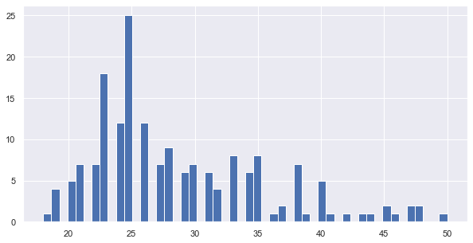

```python
plt.figure(figsize=(10,5))
plt.hist(df["Age"], bins=50) # The frequency of 25 years old customers is 25
```

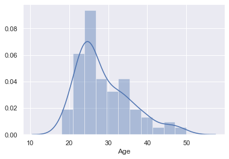

```python
sns.distplot(df["Age"], kde=True);
```

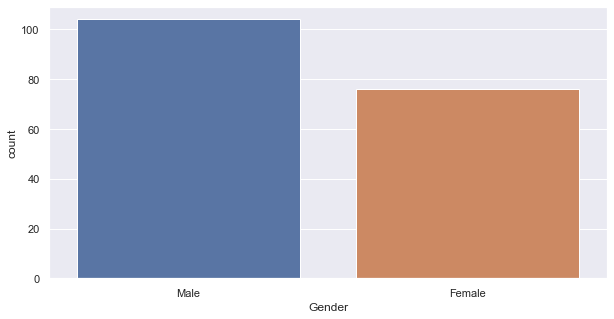

```python
plt.figure(figsize=(10,5))
sns.countplot(data=df, x= "Gender"); ##the number of male customers is higher than the number of the female customers
```

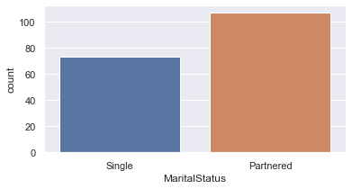

```python
plt.figure(figsize=(6,3))
sns.countplot(data=df, x= "MaritalStatus"); #The number of partnered customers is higher than the number of single customers.
```

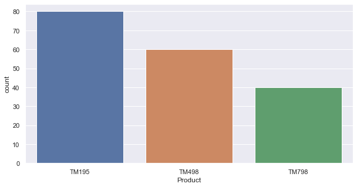

```python
plt.figure(figsize=(10,5))
sns.countplot(data=df, x= "Product"); # the number of customers who use TM195 is higher than the number of customers who use TM498 or TM798
```

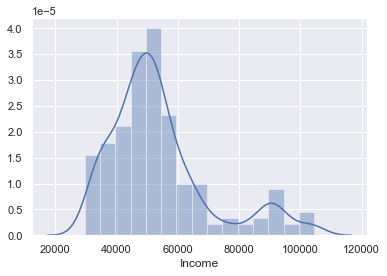

```python
sns.distplot(df["Income"]); # understand the distribution of "Income"; Income is skewed towards right
```

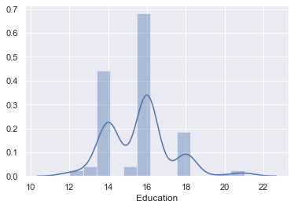

```python
sns.distplot(df["Education"]); #understand the distribution of "Education", Frequency of 16 is higher than other levels
```

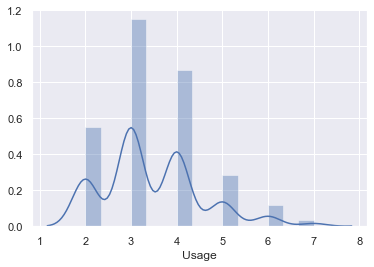

```python
sns.distplot(df["Usage"]); #understand the distribution of "Usage"; Frequency of usage 3 is higher than other usages
```

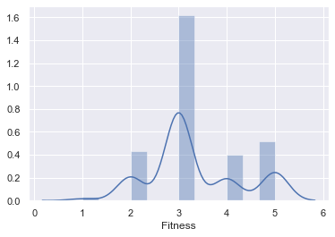

```python
sns.distplot(df["Fitness"]); #understand the distribution of "Fitness"; Frequency of 3 is higher than the other scores
```

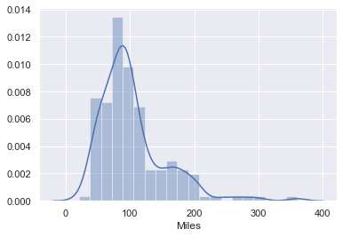

```python
sns.distplot(df["Miles"]); # understand the distribution of "Miles"; Miles is skewed towards right.
```

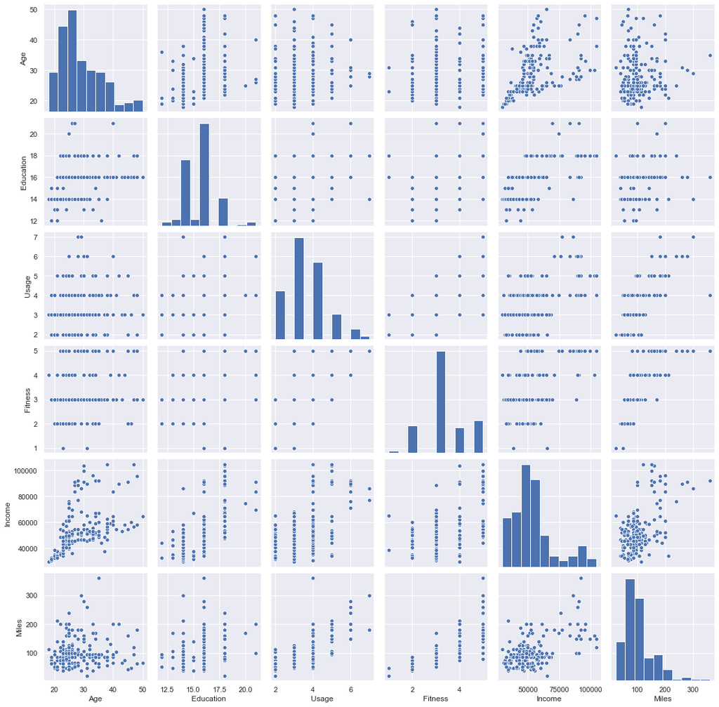

```python
sns.pairplot(df); #relationship between variables
```

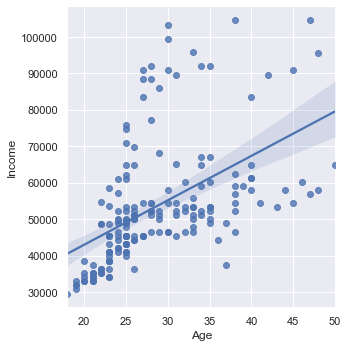

```python
sns.lmplot(x="Age", y="Income", data=df); #there is a positive correlation between age and income, age increases as income increases
```

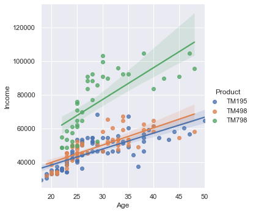

```python
sns.lmplot(x="Age", y="Income", hue="Product", data=df); # income and age relationship based on Product
```

```
<function matplotlib.pyplot.show(*args, **kw)>
```

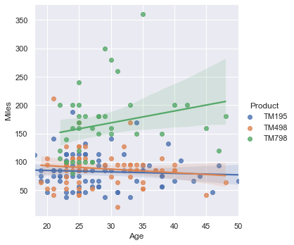

```python
sns.lmplot(x="Age", y="Miles", hue="Product", data=df); # there is a positive correlation between miles and age for TM798, but a slightly negative correlation between age and miles for TM195 AND TM498. So older customer who use TM195 or TM498 run lower miles than young customers who use TM195 or TM489
plt.show
```

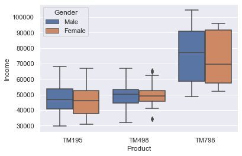

```python
sns.boxplot(x="Product", y="Income", hue="Gender", data=df) #male and female income median scores for TM195 and TM498 are very similar;The median male score is higher than the median female income scores for TM798; There are outliers for female income for TM498
```

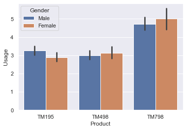

```python
sns.barplot(data=df, x="Product", y="Usage", hue="Gender"); # female usage is higher than male for TM798 and TM498, male usage is higher than female for TM195
```

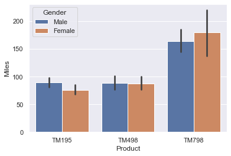

```python
sns.barplot(data=df, x="Product", y="Miles", hue="Gender");
```

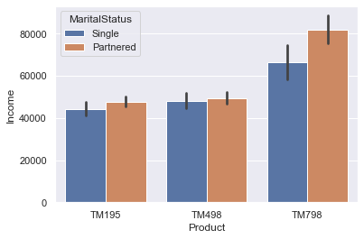

```python
sns.barplot(data=df, x="Product", y="Income", hue="MaritalStatus"); # for TM798, partnered customers' income is higher than single customers' income
```

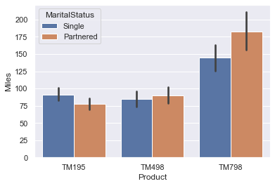

```python
sns.barplot(data=df, x="Product", y="Miles", hue="MaritalStatus");
```

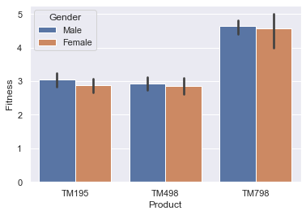

```python
sns.barplot(data=df, x="Product", y="Fitness", hue="Gender"); # not so many differences between male and female fitness scores for each product
```

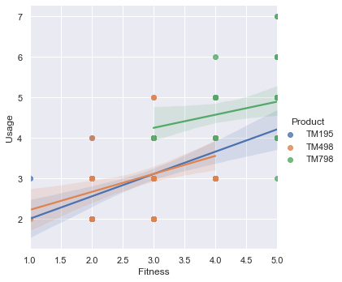

```python
sns.lmplot(x="Fitness", y="Usage", hue="Product", data=df); # postive relationship between usage and fitness
```

```python
df.corr() # look at the correlation between integer variables
```

|  | Age | Education | Usage | Fitness | Income | Miles |
| --- | --- | --- | --- | --- | --- | --- |
| Age | 1.000000 | 0.280496 | 0.015064 | 0.061105 | 0.513414 | 0.036618 |
| Education | 0.280496 | 1.000000 | 0.395155 | 0.410581 | 0.625827 | 0.307284 |
| Usage | 0.015064 | 0.395155 | 1.000000 | 0.668606 | 0.519537 | 0.759130 |
| Fitness | 0.061105 | 0.410581 | 0.668606 | 1.000000 | 0.535005 | 0.785702 |
| Income | 0.513414 | 0.625827 | 0.519537 | 0.535005 | 1.000000 | 0.543473 |
| Miles | 0.036618 | 0.307284 | 0.759130 | 0.785702 | 0.543473 | 1.000000 |

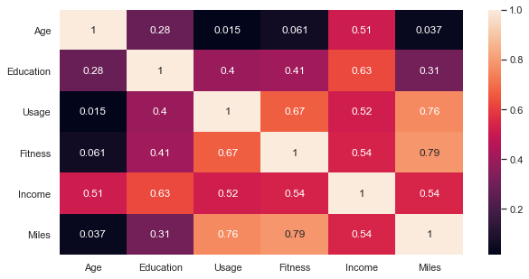

```python
plt.figure(figsize=(10,5))
sns.heatmap(df.corr(), annot=True); # there is a high correlation between Miles and usage; Fitness and Miles
```